# Dissimilarity Analysis of First 15 Diatom Samples in Nakdong River, South Korea

Muyeol Jung

10/03/2020

# Introduction

This chapter is based on the diatom analysis results of first 15 samples collected at three different sites with each five samples.

This chapter is to justify the use of diatom in water quality assessment as a methodological way to see how representative randomly chosen samples are at each site and how different they are between the sites.

### Import data set and process

First of all, all diatom counts for first 15 samples are input and saved in Excel. Then, the data set is imported and processed in R for analyses as follows.

```r
# Import the data set and transpose
D15.Count <- read.csv("Final_Diatom_List.csv", stringsAsFactors = FALSE) %>% t()

# Convert matrix to dataframe
D15.Count <- data.frame(data.matrix(D15.Count))
summary(D15.Count)

# colnames
D15_colname <- D15.Count[1,]
D15_colname <- lapply(D15_colname, as.character)


D15.Count <- D15.Count[-1,]

## Convert factors to numeric
index <- sapply(D15.Count, is.factor)
D15.Count[index] <- lapply(D15.Count[index], function(x) as.numeric(as.character(x)))

colnames(D15.Count) <- D15_colname

D15.Count

### below works

D15.Count1 <- read.csv("Final_Diatom_List.csv") %>% t()
D15.Count1 <- data.frame(data.matrix(D15.Count1))

a1 <- D15.Count1[1,]
a1 <- lapply(a1, as.character)

D15.Count1 <- D15.Count1[-1,]
colnames(D15.Count1) <- a1

D15.Count1

index <- sapply(D15.Count1, is.factor)
D15.Count1[index] <- lapply(D15.Count1[index], function(x) as.numeric(as.character(x)))
```

### Import environment data set for the sample

Import environment data for the diatom results. This data set has only Name, Site(group), and Date. I will use Site here as a grouping factor.

Site; A upstream, B midstream, C downstream

```r
D15.env <- readxl::read_xlsx("Diatom_Env.xlsx")
str(D15.env)
```

```
## Classes 'tbl_df', 'tbl' and 'data.frame':    15 obs. of  4 variables:
##  $ Name  : chr  "A1" "A2" "A3" "A4" ...
##  $ Number: num  1 2 3 4 5 1 2 3 4 5 ...
##  $ Site  : chr  "A" "A" "A" "A" ...
##  $ Date  : POSIXct, format: "2018-12-21" "2018-12-21" ...
```

### Calculate the distance: vegdist (Dissimilarity Indicies for Community Ecologists)

Command “Vegdist” will calculate distances between observations

Bray-Curtis distance scale (multiply 100) is easy to understand (0 means the samples are exactly the same, while 100 is the maximum difference that can be observed between two samples)

```r
D15.Count.dist <- vegdist(D15.Count, method = "bray")*100
D15.Count.dist
```

```
##          A1       A2       A3       A4       A5       B1       B2       B3
## A2 29.80421
## A3 37.43436 34.66205
## A4 30.70652 27.76489 33.11949
## A5 38.62434 33.23331 36.44134 20.89762
## B1 83.06138 84.47653 80.22599 83.68027 82.75584
## B2 74.35897 74.36709 70.60755 74.20781 74.23049 38.56655
## B3 81.37472 80.57922 78.54610 79.47908 79.64805 30.12939 35.21809
## B4 75.15275 79.44359 69.87179 73.75631 74.35179 49.08486 43.44624 46.05678
## B5 84.15842 84.13361 79.00791 81.56863 81.52866 38.14126 51.23251 36.92417
## C1 82.32932 83.26996 78.88101 81.96023 80.66298 69.91006 64.03191 72.53685
## C2 80.61617 81.87092 76.89422 81.11413 79.76190 69.54157 62.16216 74.57502
## C3 78.01932 78.19905 72.74633 77.19745 76.52174 69.53069 56.78131 70.77877
## C4 82.74836 83.48868 77.47253 81.69279 79.81651 71.48936 63.60153 74.66125
## C5 82.59757 82.65896 76.53214 80.77183 80.35597 71.05263 65.33149 77.02504
##          B4       B5       C1       C2       C3       C4
## A2
## A3
## A4
## A5
## B1
## B2
## B3
## B4
## B5 53.88635
## C1 69.33996 81.57216
## C2 71.89409 80.81683 23.42704
## C3 67.15468 78.99650 25.25126 17.27053
## C4 71.92982 80.67855 29.00433 24.92564 26.02586
## C5 74.83085 81.49291 30.48699 26.67946 27.15232 18.86121
```

```r
# 0: the same, 100: different
```

### Analysis of Similarities(ANOSIM)

ANOSIM provides a way to test statistically whether there is a significant difference between two or more groups of sampling units.It operates directly on a dissimilarity matrix. (uses only the rank order of dissimilarity values)

```r
D15.anosim <- with(D15.env, anosim(D15.Count.dist, Site))
summary(D15.anosim)
```

```
##
## Call:
## anosim(x = D15.Count.dist, grouping = Site)
## Dissimilarity: bray
##
## ANOSIM statistic R:     1
##       Significance: 0.001
##
## Permutation: free
## Number of permutations: 999
##
## Upper quantiles of permutations (null model):
##   90%   95% 97.5%   99%
## 0.164 0.222 0.294 0.359
##
## Dissimilarity ranks between and within classes:
##         0%   25%  50%   75% 100%  N
## Between 31 49.50 68.0 86.50  105 75
## A        3 12.75 16.5 19.50   25 10
## B       13 21.50 25.0 27.75   30 10
## C        1  4.25  6.5  8.75   14 10
```

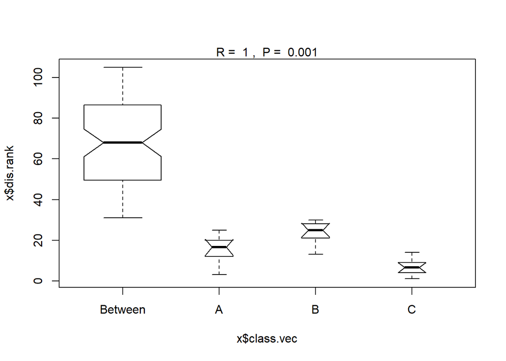

```r
plot(D15.anosim)
```

## MRPP: Multi Response Permutation Procedure and Mean Dissimilarity Matrix

mrpp for a similar function using original dissimiliarities instead of their ranks.

```
##
## Call:
## mrpp(dat = D15.Count, grouping = Site, distance = "bray")
##
## Dissimilarity index: bray
## Weights for groups:  n
##
## Class means and counts:
##
##       A      B      C
## delta 0.3227 0.4227 0.2491
## n     5      5      5
##
## Chance corrected within-group agreement A: 0.4843
## Based on observed delta 0.3315 and expected delta 0.6428
##
## Significance of delta: 0.001
## Permutation: free
## Number of permutations: 999
```

```
##          A        B        C
## A 32.26881 78.58290 79.92720
## B 78.58290 42.26862 71.66864
## C 79.92720 71.66864 24.90846
## attr(,"class")
## [1] "meandist" "matrix"
## attr(,"n")
## grouping
## A B C
## 5 5 5
```

```
##
## Mean distances:
##                 Average
## within groups  33.14863
## between groups 76.72625
## overall        64.27550
##
## Summary statistics:
##                          Statistic
## MRPP A weights n         0.4842727
## MRPP A weights n-1       0.4842727
## MRPP A weights n(n-1)    0.4842727
## Classification strength 43.5776168
```

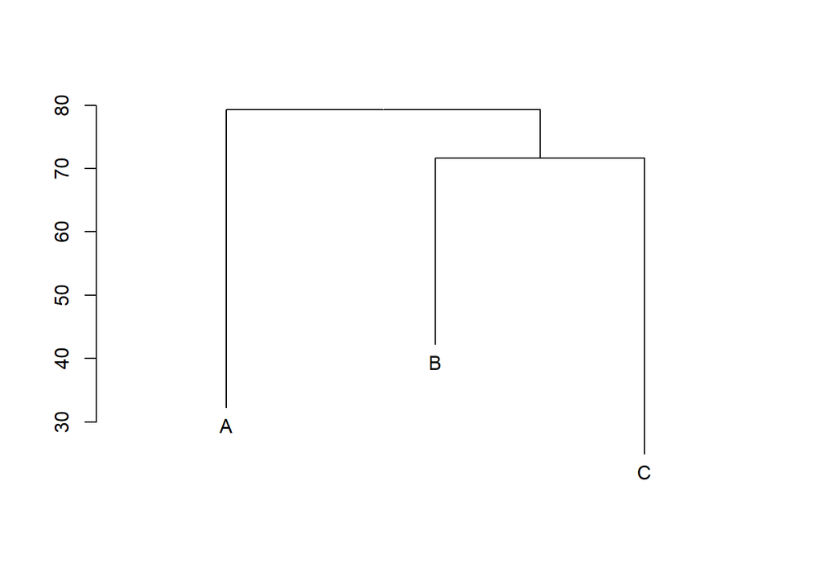

```r
D15.ordination <- metaMDS(D15.Count, distance = "bray", k=2)
```

```
## Square root transformation
## Wisconsin double standardization
## *** Solution reached
```

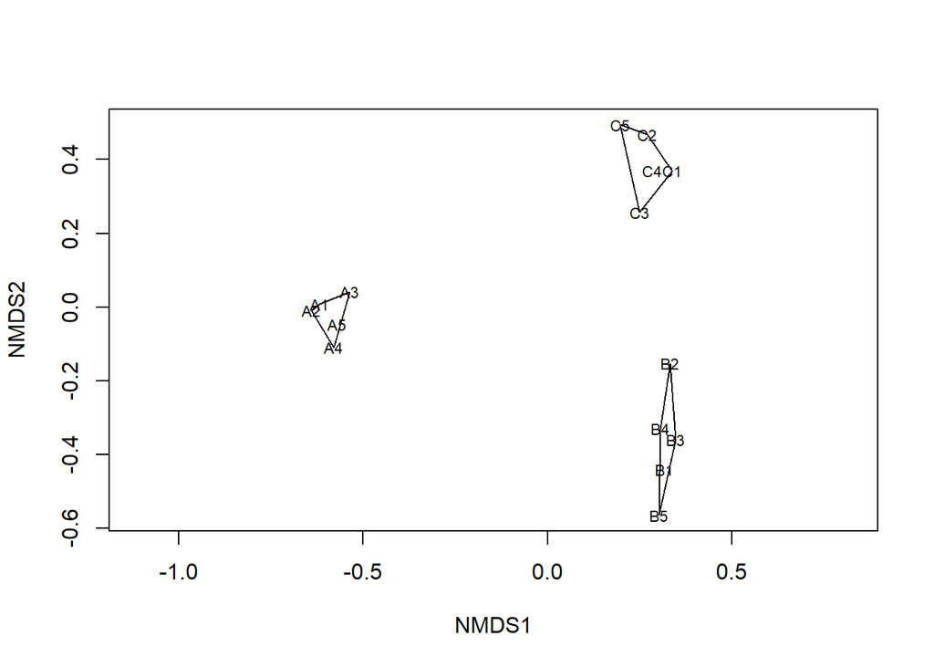

```r
plot(D15.ordination, type="t", display = "sites")
with(D15.env, ordihull(D15.ordination, Site))
```

### Conclusion

On Bray-Curtis dissimilarities, fives samples at each site are clustered, whereas far away from samples from other sites.

Samples at site C are more closely clustered followed by site A, site B is the least clustered.